# Descritivo de Remunerações do TRT13 de 2018 a 2020

# Paraíba

## TRT13 - 2018 a 2020

## Análise Descritiva

### Distribuição dos funcionários no TRT13 de 2018 a 2020

#### Geral por mês

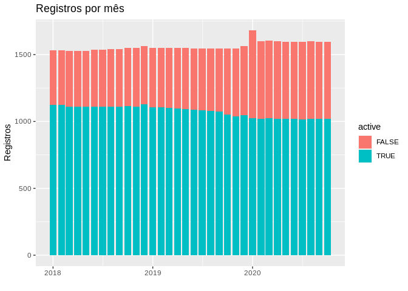

#### Ativos por tipo

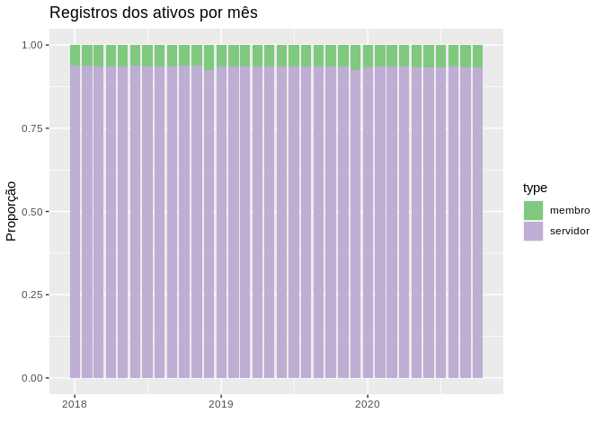

#### Distribuição geral por tipo

| Tipo | 2018 | 2019 | 2020 |
| --- | --- | --- | --- |
| membro | 99 | 98 | 97 |
| pensionista | 106 | 107 | 117 |
| servidor | 1344 | 1340 | 1382 |

- Membros: É uma classificação mais ampla que abrange todo o tipo agente público que “representa” o Poder Judiciário ou o Ministério Público.
- Servidores: Um servidor público é um funcionário da administração pública que possui um vínculo de trabalho com órgãos que fazem parte do Estado.
- Pensionistas: São beneficiários de pensão por morte de algum funcionário do poder público.

### Visão geral dos pagamentos de 2018 a 2020

Os pagamentos medianos, máximos e mínimos se deram da seguinte forma.

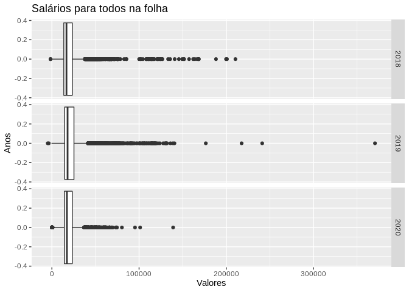

### Distribuição dos tipos dos gastos de 2018 a 2020

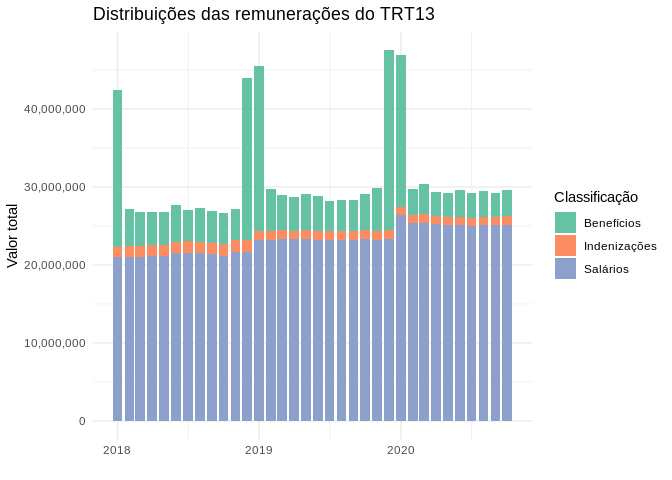

Os benefícios aqui descritos são quaisquer remunerações recebidas por um funcionário que não sejam proveniente de salários ou indenizações. Alguns exemplos de benefícios são: diárias, gratificações, remuneração por função de confiança, benefícios pessoais ou eventuais.

As indenizações, por sua vez, são valores especiais recebidos eventualmente. Por exemplo: Auxílios alimentação, moradia, transporte, natalidade, pré-escolar, ajudas de custo.

### Remunerações médias dos funcionários de acordo com seu tipo

| Ano | membro | pensionista | servidor |
| --- | --- | --- | --- |
| 2018 | 37069.25 | 12698.550 | 18499.09 |
| 2019 | 37683.92 | 9849.668 | 20152.92 |
| 2020 | 36315.78 | 14929.335 | 18671.69 |

### Distribuição das remunerações dos funcionários de acordo com seu tipo

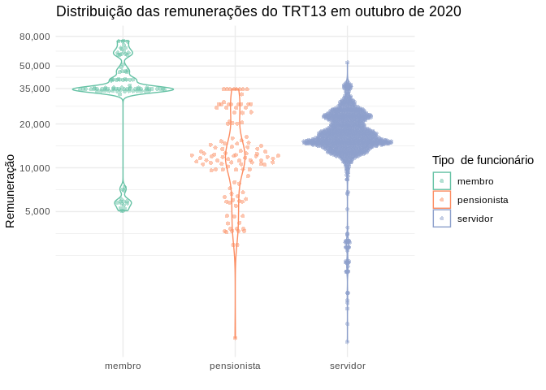

### Valores que chamam atenção

#### 2018

Neste ano 13 remunerações foram maiores que R$ 150.000,00.

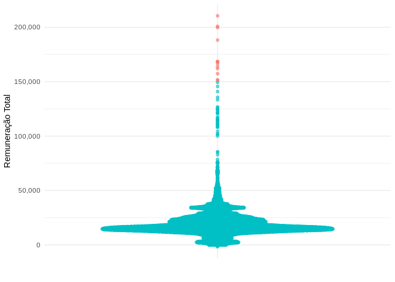

Em novembro de 2018 um Analista Judiciário recebeu um total de de **R$ 210.527,00**. Desse valor, **R$ 17.442,00** foi recebido como salário e **R$ -910,44** como indenizações. Como benefícios foi recebido um valor de **R$ 193.995,00**, maior parte deste foi atribuída como **vantagens eventuais***. Outros analistas e juízes têm uma distribuição parecida.

*Vantagens eventuais podem ser: Abono constitucional de 1/3 de férias, indenização de férias, antecipação de férias, serviço extraordinário, substituição, pagamentos retroativos, além de outras desta natureza. Valores pagos a título de Adicional de Insalubridade ou de Periculosidade, Adicional Noturno.

#### 2019

Neste ano 4 remunerações foram maiores que R$ 150.000,00.

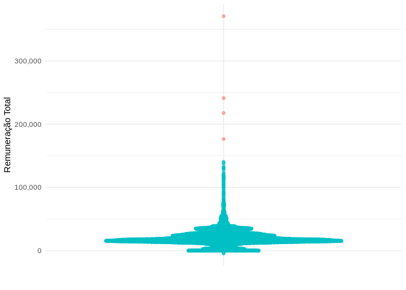

Em maio de 2019 um Analista Judiciário recebeu um total de de **R$ 370.603,00 R$**. Desse valor foi recebido **R$ 22.013,00** de salário, **R$ 1.804,00** em indenizações. Já em benefícios foi recebido um valor de **R$ 346.786,00**, sendo em sua maior parte devido a **vantagens eventuais**. Outros analistas tem uma distribuição parecida no mesmo ano.

#### 2020

Neste ano não se observam remunerações da mesma magnitude dos anos anteriores até então (out/2020).

### Distribuição das remunerações de 2018 a 2020

#### Média dos salários por ano

| Ano | Média |
| --- | --- |
| 2018 | 19315.66 |
| 2019 | 20568.16 |
| 2020 | 19458.43 |

#### Distribuição dos salários por ano

A distribuição das remunerações em 2018 é bastante ampla, existem funcionários com remuneração acima de **R$ 200.000,00** e outros com remuneração abaixo de **R$ 5.000,00**. A média salárial foi de **R$ 19.316,00**

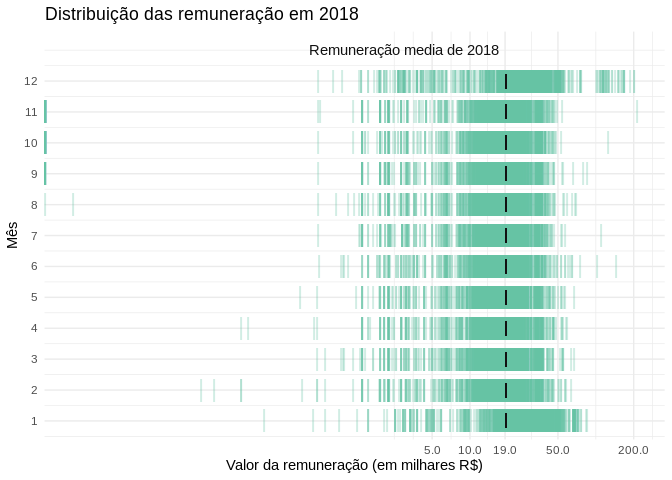

Em 2019 existem funcinários com remuneração acima de **R$ 300.000,00** e outros com remuneração abaixo de **R$ 5.000,00**. A média salárial foi de **R$ 20.568,00**

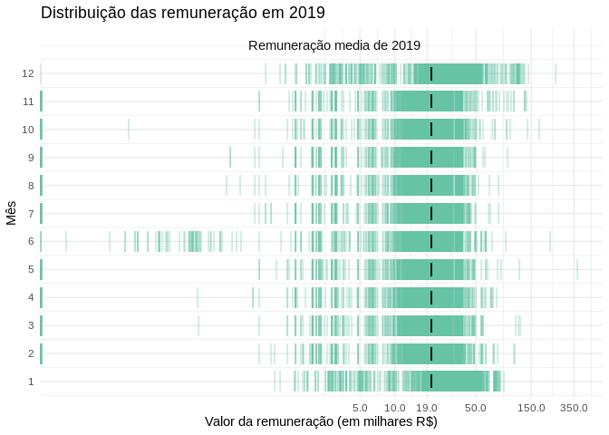

Em 2020 existem funcinários com remuneração acima de **R$ 100.000,00** e outros com remuneração abaixo de **R$ 5.000,00**. A média salárial foi de **R$ 19.458,00**, até então.

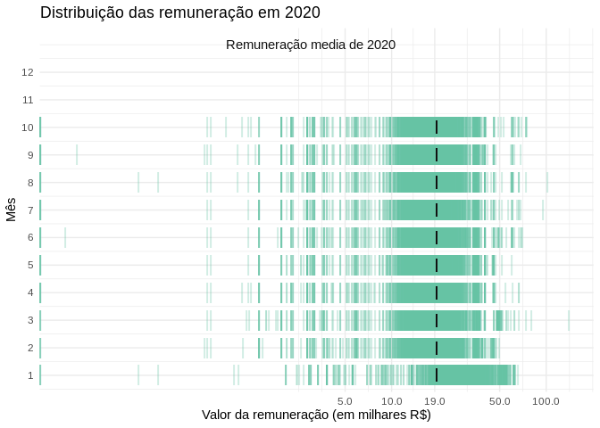

### Distribuição das remunerações por cargo

Os Juízes do TRT13 são os que apresentam as maiores remunerações. Logo após estão os Analistas Judiciários. Em terceiro têm-se os Técnicos Judiciários. As categorias Sem Vínculo, Auxiliar Judiciário e e Outros são minoria no TRT13 e apresentam as menores remunerações.

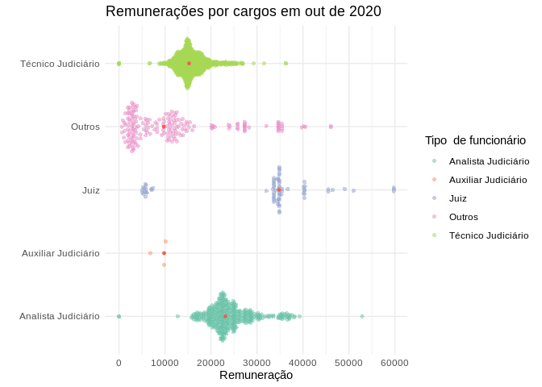

### Distribuição dos tipos de auxílios e indenizações

#### Benefícios

| Ano | Benefícios Eventuais | Benefícios Pessoais | Total |
| --- | --- | --- | --- |
| 2018 | 37811560 | 43430192 | 83661414 |
| 2019 | 44943478 | 42526669 | 89581726 |
| 2020 | 7085559 | 31706410 | 49112035 |

Benefícios Permanentes (funds_personal_benefits) são os benefícios adquiridos judicialmente e outros benefícios pessoais. Benefícios Eventuais (funds_eventual_benefits), são benefícios como bônus de natal e férias.

[figure not shown]

A fonte principal dos aumentos nos benefícios recorrentes em janeiro e dezembro são benefícios eventuais, como bônus e férias (funds_eventual_benefits).

Observa-se uma diminuição, em janeiro de 2020, no total de benefícios eventuais recebidos, em comparação com os anos anteriores.

#### Indenizações

| Ano | Total |
| --- | --- |
| 2018 | 17533261 |
| 2019 | 13550323 |
| 2020 | 10630964 |

O único valor presente é o referente ao total das indenizações (perks_total). As indenizações específicas não possuem valores associados. **perks_pecuniary**, **perks_food**, **perks_health**, **perks_compensatory_leave**, **perks_birth**, **perks_housing**, **perks_subsistence**, **perks_vacation**, **perks_transportation**, **perks_pre_school**, **perks_vacation_pecuniary**, **perks_furniture_transport**, **perks_premium_license_pecuniary** são todos NA, em todos os anos.

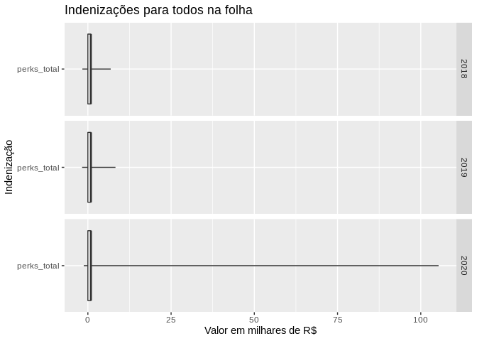

Um valor chama atenção em 2020. Em março, um Juiz Titular de Vara - Nível Superior JTJT, inativo, recebeu **R$ 105.353,00** de indenização, valor quase três vezes mais alto que o segundo maior no mesmo ano.

#### Por membros ativos

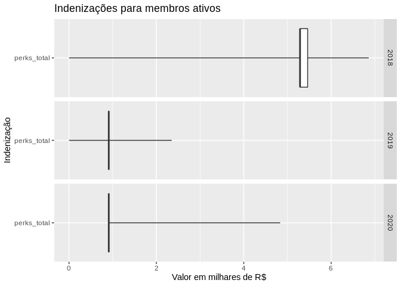

### Distribuição dos cargos em outubro de 2020

| Cargo | Quantidade |
| --- | --- |
| TÉCNICO JUDICIÁRIO | 926 |
| ANALISTA JUDICIÁRIO | 395 |
| NA | 115 |
| JUIZ TITULAR DE VARA - NÍVEL SUPERIOR JTJT | 35 |
| JUIZ SUBSTITUTO - NÍVEL SUPERIOR JSJS | 31 |
| PENSIONISTA | 29 |
| JUIZ CLASSISTA - NÍVEL FUNDAMENTAL JCJC | 15 |
| DESEMBARGADOR FEDERAL - NÍVEL SUPERIOR DFDF | 14 |
| ASSISTENTE IV - FC-04 | 6 |
| ASSISTENTE III - FC-03 | 4 |
| ASSISTENTE DE GABINETE V - FC-05 | 3 |
| AUXILIAR JUDICIÁRIO | 3 |
| SECRETARIO DE AUDIENCIA - FC-04 | 3 |
| ASSISTENTE V - FC-05 | 2 |
| COORDENADOR - CJ-02 | 2 |
| JUIZ TITULAR DE VARA - NÍVEL SUPERIOR DFDF | 2 |
| ASSESSOR DE COMUNICAÇÃO SOCIAL - CJ-02 | 1 |
| ASSESSOR DE GESTÃO ESTRATÉGICA - CJ-02 | 1 |
| ASSISTENTE 5-APOIO AS PAUTAS E SESSÕES - FC-05 | 1 |
| ASSISTENTE DE DIRETOR - FC-05 | 1 |
| ASSISTENTE DE GABINETE IV - FC-04 | 1 |
| ASSISTENTE I - FC-01 | 1 |
| ASSISTENTE II - FC-02 | 1 |
| CALCULISTA - FC-04 | 1 |
| CHEFE DA SEÇÃO DE PROCESSOS - FC-05 | 1 |
| CHEFE DO NUCLEO DE JORNALISMO E MIDIAS SOCIAIS - FC-06 | 1 |
| SECRETÁRIO DA CORREGEDORIA - CJ-03 | 1 |